# DDS 8521 wk 7 Assignment 7

Jemael Nzihou

2025-02-20

### Develop a Model to Predict Used Home Prices Using Multiple Regression

The goal was to develop a Model to Predict Used Home Prices Using Multiple Regression. The assignment will incorporate a project developed in R, a report presenting the results. Introduction The assignment is to explore how to construct, analyze, and refine a multiple regression model using a House Prices, Advanced Regression Techniques (https://shorturl.at/cGigI) dataset. The task was to optimize the model based on degrees of freedom, the F score, and the number of predictors, providing a detailed rationale for the different steps taken. This dataset includes various features related to residential homes in Ames, Iowa, and their sale prices, making it an excellent candidate for multiple regression analysis.

```r
#Load the dataset

houseprice <- read.csv("C:/Users/jemae/Downloads/DDS-8521 v1 Statistical Modeling/House-prices-advanced-regression-techniques .csv", header=TRUE)
#houseprice<- House.prices.advanced.regression.techniques.
```

### Data Exploration and Preprocessing:

#### 1. Start by exploring the dataset to understand the features available.

Identify continuous, categorical, and ordinal variables.

```r
# Check the dimensions (number of rows and columns)
dim(houseprice)
```

```
## [1] 2919   84
```

dim(houseprice) Displays the number of rows (observations) and columns (features).

```r
# Display the first few rows of the dataset
head(houseprice)
```

```
##     Id MSSubClass MSZoning LotFrontage LotArea Street Alley LotShape
## 1 1461         20       RH          80   11622   Pave  <NA>      Reg
## 2 1462         20       RL          81   14267   Pave  <NA>      IR1
## 3 1463         60       RL          74   13830   Pave  <NA>      IR1
## 4 1464         60       RL          78    9978   Pave  <NA>      IR1
## 5 1465        120       RL          43    5005   Pave  <NA>      IR1
## 6 1466         60       RL          75   10000   Pave  <NA>      IR1
##   LandContour Utilities LotConfig LandSlope Neighborhood Condition1 Condition2
## 1         Lvl    AllPub    Inside       Gtl        NAmes      Feedr       Norm
## 2         Lvl    AllPub    Corner       Gtl        NAmes       Norm       Norm
## 3         Lvl    AllPub    Inside       Gtl      Gilbert       Norm       Norm
## 4         Lvl    AllPub    Inside       Gtl      Gilbert       Norm       Norm
## 5         HLS    AllPub    Inside       Gtl      StoneBr       Norm       Norm
## 6         Lvl    AllPub    Corner       Gtl      Gilbert       Norm       Norm
##   BldgType HouseStyle OverallQual OverallCond YearBuilt YearRemodAdd RoofStyle
```

[output cut: 76 more lines]

head(houseprice) Shows the first few rows to get a preview of the dataset.

# Display the last few rows of the dataset

```r
tail(houseprice)
```

```
##        Id MSSubClass MSZoning LotFrontage LotArea Street Alley LotShape
## 2914 1455         20       FV          62    7500   Pave  Pave      Reg
## 2915 1456         60       RL          62    7917   Pave  <NA>      Reg
## 2916 1457         20       RL          85   13175   Pave  <NA>      Reg
## 2917 1458         70       RL          66    9042   Pave  <NA>      Reg
## 2918 1459         20       RL          68    9717   Pave  <NA>      Reg
## 2919 1460         20       RL          75    9937   Pave  <NA>      Reg
##      LandContour Utilities LotConfig LandSlope Neighborhood Condition1
## 2914         Lvl    AllPub    Inside       Gtl      Somerst       Norm
## 2915         Lvl    AllPub    Inside       Gtl      Gilbert       Norm
## 2916         Lvl    AllPub    Inside       Gtl       NWAmes       Norm
## 2917         Lvl    AllPub    Inside       Gtl      Crawfor       Norm
## 2918         Lvl    AllPub    Inside       Gtl        NAmes       Norm
## 2919         Lvl    AllPub    Inside       Gtl      Edwards       Norm
##      Condition2 BldgType HouseStyle OverallQual OverallCond YearBuilt
```

[output cut: 76 more lines]

tail(houseprice) shows the last few rows to get a preview of the dataset.

```r
# Get an overview of the dataset structure (column names, types, etc.)
str(houseprice)
```

```
## 'data.frame':    2919 obs. of  84 variables:
##  $ Id           : int  1461 1462 1463 1464 1465 1466 1467 1468 1469 1470 ...
##  $ MSSubClass   : int  20 20 60 60 120 60 20 60 20 20 ...
##  $ MSZoning     : chr  "RH" "RL" "RL" "RL" ...
##  $ LotFrontage  : int  80 81 74 78 43 75 NA 63 85 70 ...
##  $ LotArea      : int  11622 14267 13830 9978 5005 10000 7980 8402 10176 8400 ...
##  $ Street       : chr  "Pave" "Pave" "Pave" "Pave" ...
##  $ Alley        : chr  NA NA NA NA ...
##  $ LotShape     : chr  "Reg" "IR1" "IR1" "IR1" ...
##  $ LandContour  : chr  "Lvl" "Lvl" "Lvl" "Lvl" ...
##  $ Utilities    : chr  "AllPub" "AllPub" "AllPub" "AllPub" ...
##  $ LotConfig    : chr  "Inside" "Corner" "Inside" "Inside" ...
##  $ LandSlope    : chr  "Gtl" "Gtl" "Gtl" "Gtl" ...
##  $ Neighborhood : chr  "NAmes" "NAmes" "Gilbert" "Gilbert" ...
##  $ Condition1   : chr  "Feedr" "Norm" "Norm" "Norm" ...
```

[output cut: 70 more lines]

str(houseprice) Provides information about the structure, including column names, data types. there is character(Chr) type of variable and integer (int) on V81 which contains NA

```r
# View colums names in the data set
colnames(houseprice)
```

```
##  [1] "Id"            "MSSubClass"    "MSZoning"      "LotFrontage"
##  [5] "LotArea"       "Street"        "Alley"         "LotShape"
##  [9] "LandContour"   "Utilities"     "LotConfig"     "LandSlope"
## [13] "Neighborhood"  "Condition1"    "Condition2"    "BldgType"
## [17] "HouseStyle"    "OverallQual"   "OverallCond"   "YearBuilt"
## [21] "YearRemodAdd"  "RoofStyle"     "RoofMatl"      "Exterior1st"
## [25] "Exterior2nd"   "MasVnrType"    "MasVnrArea"    "ExterQual"
## [29] "ExterCond"     "Foundation"    "BsmtQual"      "BsmtCond"
## [33] "BsmtExposure"  "BsmtFinType1"  "BsmtFinSF1"    "BsmtFinType2"
## [37] "BsmtFinSF2"    "BsmtUnfSF"     "TotalBsmtSF"   "Heating"
## [41] "HeatingQC"     "CentralAir"    "Electrical"    "X1stFlrSF"
## [45] "X2ndFlrSF"     "LowQualFinSF"  "GrLivArea"     "BsmtFullBath"
## [49] "BsmtHalfBath"  "FullBath"      "HalfBath"      "BedroomAbvGr"
## [53] "KitchenAbvGr"  "KitchenQual"   "TotRmsAbvGrd"  "Functional"
## [57] "Fireplaces"    "FireplaceQu"   "GarageType"    "GarageYrBlt"
## [61] "GarageFinish"  "GarageCars"    "GarageArea"    "GarageQual"
## [65] "GarageCond"    "PavedDrive"    "WoodDeckSF"    "OpenPorchSF"
## [69] "EnclosedPorch" "X3SsnPorch"    "ScreenPorch"   "PoolArea"
## [73] "PoolQC"        "Fence"         "MiscFeature"   "MiscVal"
## [77] "MoSold"        "YrSold"        "SaleType"      "SaleCondition"
## [81] "SalePrice"     "X"             "X.1"           "X.2"
```

```r
# Summarize each column to understand the distribution
summary(houseprice)
```

```
##        Id           MSSubClass       MSZoning          LotFrontage
##  Min.   :   1.0   Min.   : 20.00   Length:2919        Min.   : 21.00
##  1st Qu.: 730.5   1st Qu.: 20.00   Class :character   1st Qu.: 59.00
##  Median :1460.0   Median : 50.00   Mode  :character   Median : 68.00
##  Mean   :1460.0   Mean   : 57.14                      Mean   : 69.31
##  3rd Qu.:2189.5   3rd Qu.: 70.00                      3rd Qu.: 80.00
##  Max.   :2919.0   Max.   :190.00                      Max.   :313.00
##                                                       NA's   :486
##     LotArea          Street             Alley             LotShape
##  Min.   :  1300   Length:2919        Length:2919        Length:2919
##  1st Qu.:  7478   Class :character   Class :character   Class :character
##  Median :  9453   Mode  :character   Mode  :character   Mode  :character
##  Mean   : 10168
##  3rd Qu.: 11570
##  Max.   :215245
##
##  LandContour         Utilities          LotConfig          LandSlope
##  Length:2919        Length:2919        Length:2919        Length:2919
##  Class :character   Class :character   Class :character   Class :character
##  Mode  :character   Mode  :character   Mode  :character   Mode  :character
##
##
##
##
##  Neighborhood        Condition1         Condition2          BldgType
##  Length:2919        Length:2919        Length:2919        Length:2919
##  Class :character   Class :character   Class :character   Class :character
##  Mode  :character   Mode  :character   Mode  :character   Mode  :character
##
##
##
##
##   HouseStyle         OverallQual      OverallCond      YearBuilt
##  Length:2919        Min.   : 1.000   Min.   :1.000   Min.   :1872
##  Class :character   1st Qu.: 5.000   1st Qu.:5.000   1st Qu.:1954
##  Mode  :character   Median : 6.000   Median :5.000   Median :1973
##                     Mean   : 6.089   Mean   :5.565   Mean   :1971
##                     3rd Qu.: 7.000   3rd Qu.:6.000   3rd Qu.:2001
##                     Max.   :10.000   Max.   :9.000   Max.   :2010
##
```

[output cut: 113 more lines]

```
##  Min.   : 1.000   Min.   :2006   Length:2919        Length:2919
##  1st Qu.: 4.000   1st Qu.:2007   Class :character   Class :character
##  Median : 6.000   Median :2008   Mode  :character   Mode  :character
##  Mean   : 6.213   Mean   :2008
##  3rd Qu.: 8.000   3rd Qu.:2009
##  Max.   :12.000   Max.   :2010
##
##    SalePrice         X             X.1               X.2
##  Min.   : 34900   Mode:logical   Mode:logical   Min.   :163000
##  1st Qu.:163000   NA's:2919      NA's:2919      1st Qu.:163000
##  Median :163000                                 Median :163000
##  Mean   :171964                                 Mean   :163000
##  3rd Qu.:163000                                 3rd Qu.:163000
##  Max.   :755000                                 Max.   :163000
##                                                 NA's   :2918
```

summary(houseprice) gives summary statistics like min, max, mean, and quartiles for numeric variables and counts for categorical variables.

#### 1b. Identify Data Types: Continuous, Categorical, and Ordinal Variables

We categorize the features into continuous, categorical, and ordinal variables.

```r
# Identify categorical variables (non-numeric variables)
categorical_vars <- names(houseprice)[sapply(houseprice, is.character)]
print("Categorical Variables:")
```

```
## [1] "Categorical Variables:"
```

```r
print(categorical_vars)
```

```
##  [1] "MSZoning"      "Street"        "Alley"         "LotShape"
##  [5] "LandContour"   "Utilities"     "LotConfig"     "LandSlope"
##  [9] "Neighborhood"  "Condition1"    "Condition2"    "BldgType"
## [13] "HouseStyle"    "RoofStyle"     "RoofMatl"      "Exterior1st"
## [17] "Exterior2nd"   "MasVnrType"    "ExterQual"     "ExterCond"
## [21] "Foundation"    "BsmtQual"      "BsmtCond"      "BsmtExposure"
## [25] "BsmtFinType1"  "BsmtFinType2"  "Heating"       "HeatingQC"
## [29] "CentralAir"    "Electrical"    "KitchenQual"   "Functional"
## [33] "FireplaceQu"   "GarageType"    "GarageFinish"  "GarageQual"
## [37] "GarageCond"    "PavedDrive"    "PoolQC"        "Fence"
## [41] "MiscFeature"   "SaleType"      "SaleCondition"
```

```r
# Identify numerical variables
numeric_vars <- names(houseprice)[sapply(houseprice, is.numeric)]
print("Numerical Variables:")
```

```
## [1] "Numerical Variables:"
```

```r
print(numeric_vars)
```

```
##  [1] "Id"            "MSSubClass"    "LotFrontage"   "LotArea"
##  [5] "OverallQual"   "OverallCond"   "YearBuilt"     "YearRemodAdd"
##  [9] "MasVnrArea"    "BsmtFinSF1"    "BsmtFinSF2"    "BsmtUnfSF"
## [13] "TotalBsmtSF"   "X1stFlrSF"     "X2ndFlrSF"     "LowQualFinSF"
## [17] "GrLivArea"     "BsmtFullBath"  "BsmtHalfBath"  "FullBath"
## [21] "HalfBath"      "BedroomAbvGr"  "KitchenAbvGr"  "TotRmsAbvGrd"
## [25] "Fireplaces"    "GarageYrBlt"   "GarageCars"    "GarageArea"
## [29] "WoodDeckSF"    "OpenPorchSF"   "EnclosedPorch" "X3SsnPorch"
## [33] "ScreenPorch"   "PoolArea"      "MiscVal"       "MoSold"
## [37] "YrSold"        "SalePrice"     "X.2"
```

```r
# Check if there are any ordinal variables (categorical variables with meaningful order)
# Example: 'OverallQual' and 'OverallCond' in the dataset are ordinal
ordinal_vars <- c("OverallQual", "OverallCond") # These columns have ordered values (1-10 rating)
print("Ordinal Variables:")
```

```
## [1] "Ordinal Variables:"
```

```r
print(ordinal_vars)
```

```
## [1] "OverallQual" "OverallCond"
```

#### Explanation

sapply(houseprice, is.character): Identifies categorical variables (text-based). sapply(houseprice, is.numeric): Identifies continuous variables (numeric). Ordinal variables are categorical variables that follow a natural order (e.g., rating scales like OverallQual and OverallCond).

#### 2. Clean the data by handling missing values, outliers, and any erroneous data points as you see fit.

#### Documentation of preprocessing steps and justification of choices.

Data cleaning is done to ensure our model works with high-quality data.

#### Handling Missing Values

First, let’s check the number of missing values in each column:

```r
# Check missing values for each column
missing_values <- colSums(is.na(houseprice))
missing_values <- missing_values[missing_values > 0]  # Filter only columns with missing values
print(missing_values)
```

```
##     MSZoning  LotFrontage        Alley    Utilities  Exterior1st  Exterior2nd
##            4          486         2721            2            1            1
##   MasVnrType   MasVnrArea     BsmtQual     BsmtCond BsmtExposure BsmtFinType1
##           24           23           81           82           82           79
##   BsmtFinSF1 BsmtFinType2   BsmtFinSF2    BsmtUnfSF  TotalBsmtSF   Electrical
##            1           80            1            1            1            1
## BsmtFullBath BsmtHalfBath  KitchenQual   Functional  FireplaceQu   GarageType
##            2            2            1            2         1420          157
##  GarageYrBlt GarageFinish   GarageCars   GarageArea   GarageQual   GarageCond
##          159          159            1            1          159          159
##       PoolQC        Fence  MiscFeature     SaleType            X          X.1
##         2909         2348         2814            1         2919         2919
##          X.2
##         2918
```

#### Approach to Handling Missing Values

If a column has more than 30% missing values, it might be better to drop the column to avoid bias. For numerical features, we can replace missing values with median (robust to outliers). For categorical features, we can fill missing values with the mode (most frequent category).

#### Implementation

```r
# Drop columns with more than 30% missing values
threshold <- 0.3 * nrow(houseprice)
columns_to_drop <- names(missing_values[missing_values > threshold])
houseprice <- houseprice[, !(names(houseprice) %in% columns_to_drop)]
print(paste("Dropped columns:", paste(columns_to_drop, collapse=", ")))
```

```
## [1] "Dropped columns: Alley, FireplaceQu, PoolQC, Fence, MiscFeature, X, X.1, X.2"
```

```r
# Impute missing values for numerical variables with the median
for (col in names(houseprice)) {
  if (is.numeric(houseprice[[col]]) && sum(is.na(houseprice[[col]])) > 0) {
    houseprice[[col]][is.na(houseprice[[col]])] <- median(houseprice[[col]], na.rm = TRUE)
  }
}

# Impute missing values for categorical variables with the mode
fill_mode <- function(x) {
  ux <- unique(na.omit(x))
  ux[which.max(tabulate(match(x, ux)))]
}

for (col in names(houseprice)) {
  if (is.character(houseprice[[col]]) && sum(is.na(houseprice[[col]])) > 0) {
    houseprice[[col]][is.na(houseprice[[col]])] <- fill_mode(houseprice[[col]])
  }
}

# Verify missing values after imputation
print(sum(is.na(houseprice)))  # Should be 0
```

```
## [1] 0
```

##### Justification

Dropping highly missing columns prevents excessive imputation bias. Using the median for numeric data prevents distortion from outliers. Using the mode for categorical data ensures consistency without adding new categories.

#### Handling Outliers

Outliers can distort models, so we detect and remove them using the interquartile range (IQR) method.

```r
# Function to remove outliers based on IQR
remove_outliers <- function(data, cols) {
  for (col in cols) {
    if (is.numeric(data[[col]])) {
      Q1 <- quantile(data[[col]], 0.25, na.rm = TRUE)
      Q3 <- quantile(data[[col]], 0.75, na.rm = TRUE)
      IQR <- Q3 - Q1
      lower_bound <- Q1 - 1.5 * IQR
      upper_bound <- Q3 + 1.5 * IQR
      data <- data[data[[col]] >= lower_bound & data[[col]] <= upper_bound, ]
    }
  }
  return(data)
}

# Apply outlier removal to numerical variables
houseprice <- remove_outliers(houseprice, numeric_vars)

# Check new dimensions after removing outliers
dim(houseprice)
```

```
## [1] 784  76
```

#### Handling Erroneous Data Points

Some values may be logically incorrect. For example, square footage should be positive, and year built should be within a reasonable range.

```r
# Check if the column exists before filtering
if ("TotalBsmtSF" %in% colnames(houseprice) & "GrLivArea" %in% colnames(houseprice)) {
  houseprice <- subset(houseprice, TotalBsmtSF >= 0 & GrLivArea >= 100)
} else {
  print("TotalBsmtSF or GrLivArea column not found. Skipping this filter.")
}

if ("YearBuilt" %in% colnames(houseprice)) {
  houseprice <- subset(houseprice, YearBuilt > 1800 & YearBuilt <= as.numeric(format(Sys.Date(), "%Y")))
} else {
  print("YearBuilt column not found. Skipping this filter.")
}

# Verify data quality
summary(houseprice)
```

```
##        Id         MSSubClass       MSZoning          LotFrontage
##  Min.   :  19   Min.   : 20.00   Length:784         Min.   : 30.00
##  1st Qu.:1140   1st Qu.: 20.00   Class :character   1st Qu.: 62.00
##  Median :1859   Median : 60.00   Mode  :character   Median : 68.00
##  Mean   :1723   Mean   : 51.56                      Mean   : 68.19
##  3rd Qu.:2342   3rd Qu.: 60.00                      3rd Qu.: 75.00
##  Max.   :2919   Max.   :120.00                      Max.   :110.00
##     LotArea         Street            LotShape         LandContour
##  Min.   : 2887   Length:784         Length:784         Length:784
##  1st Qu.: 7690   Class :character   Class :character   Class :character
##  Median : 9092   Mode  :character   Mode  :character   Mode  :character
##  Mean   : 9144
##  3rd Qu.:10727
##  Max.   :17043
##   Utilities          LotConfig          LandSlope         Neighborhood
##  Length:784         Length:784         Length:784         Length:784
##  Class :character   Class :character   Class :character   Class :character
##  Mode  :character   Mode  :character   Mode  :character   Mode  :character
##
##
##
##   Condition1         Condition2          BldgType          HouseStyle
##  Length:784         Length:784         Length:784         Length:784
##  Class :character   Class :character   Class :character   Class :character
##  Mode  :character   Mode  :character   Mode  :character   Mode  :character
##
##
##
##   OverallQual     OverallCond      YearBuilt     YearRemodAdd
##  Min.   :2.000   Min.   :4.000   Min.   :1890   Min.   :1950
##  1st Qu.:5.000   1st Qu.:5.000   1st Qu.:1968   1st Qu.:1976
##  Median :6.000   Median :5.000   Median :1997   Median :1999
##  Mean   :6.334   Mean   :5.353   Mean   :1985   Mean   :1990
##  3rd Qu.:7.000   3rd Qu.:6.000   3rd Qu.:2005   3rd Qu.:2005
##  Max.   :9.000   Max.   :7.000   Max.   :2010   Max.   :2010
##   RoofStyle           RoofMatl         Exterior1st        Exterior2nd
##  Length:784         Length:784         Length:784         Length:784
##  Class :character   Class :character   Class :character   Class :character
##  Mode  :character   Mode  :character   Mode  :character   Mode  :character
##
```

[output cut: 78 more lines]

```
##  Max.   :178.0   Max.   :0     Max.   :0    Max.   :0    Max.   :0
##     MiscVal      MoSold           YrSold       SaleType
##  Min.   :0   Min.   : 1.000   Min.   :2006   Length:784
##  1st Qu.:0   1st Qu.: 4.000   1st Qu.:2007   Class :character
##  Median :0   Median : 6.000   Median :2008   Mode  :character
##  Mean   :0   Mean   : 6.047   Mean   :2008
##  3rd Qu.:0   3rd Qu.: 8.000   3rd Qu.:2009
##  Max.   :0   Max.   :12.000   Max.   :2010
##  SaleCondition        SalePrice
##  Length:784         Min.   :138500
##  Class :character   1st Qu.:163000
##  Mode  :character   Median :163000
##                     Mean   :165531
##                     3rd Qu.:163000
##                     Max.   :204000
```

#### Final Steps: Verifying the Cleaned Dataset

After data cleaning, we check the final dataset.

```r
# Display summary of cleaned data
summary(houseprice)
```

```
##        Id         MSSubClass       MSZoning          LotFrontage
##  Min.   :  19   Min.   : 20.00   Length:784         Min.   : 30.00
##  1st Qu.:1140   1st Qu.: 20.00   Class :character   1st Qu.: 62.00
##  Median :1859   Median : 60.00   Mode  :character   Median : 68.00
##  Mean   :1723   Mean   : 51.56                      Mean   : 68.19
##  3rd Qu.:2342   3rd Qu.: 60.00                      3rd Qu.: 75.00
##  Max.   :2919   Max.   :120.00                      Max.   :110.00
##     LotArea         Street            LotShape         LandContour
##  Min.   : 2887   Length:784         Length:784         Length:784
##  1st Qu.: 7690   Class :character   Class :character   Class :character
##  Median : 9092   Mode  :character   Mode  :character   Mode  :character
##  Mean   : 9144
##  3rd Qu.:10727
##  Max.   :17043
##   Utilities          LotConfig          LandSlope         Neighborhood
##  Length:784         Length:784         Length:784         Length:784
##  Class :character   Class :character   Class :character   Class :character
##  Mode  :character   Mode  :character   Mode  :character   Mode  :character
##
##
##
##   Condition1         Condition2          BldgType          HouseStyle
##  Length:784         Length:784         Length:784         Length:784
##  Class :character   Class :character   Class :character   Class :character
##  Mode  :character   Mode  :character   Mode  :character   Mode  :character
##
##
##
##   OverallQual     OverallCond      YearBuilt     YearRemodAdd
##  Min.   :2.000   Min.   :4.000   Min.   :1890   Min.   :1950
##  1st Qu.:5.000   1st Qu.:5.000   1st Qu.:1968   1st Qu.:1976
##  Median :6.000   Median :5.000   Median :1997   Median :1999
##  Mean   :6.334   Mean   :5.353   Mean   :1985   Mean   :1990
##  3rd Qu.:7.000   3rd Qu.:6.000   3rd Qu.:2005   3rd Qu.:2005
##  Max.   :9.000   Max.   :7.000   Max.   :2010   Max.   :2010
##   RoofStyle           RoofMatl         Exterior1st        Exterior2nd
##  Length:784         Length:784         Length:784         Length:784
##  Class :character   Class :character   Class :character   Class :character
##  Mode  :character   Mode  :character   Mode  :character   Mode  :character
##
```

[output cut: 78 more lines]

```
##  Max.   :178.0   Max.   :0     Max.   :0    Max.   :0    Max.   :0
##     MiscVal      MoSold           YrSold       SaleType
##  Min.   :0   Min.   : 1.000   Min.   :2006   Length:784
##  1st Qu.:0   1st Qu.: 4.000   1st Qu.:2007   Class :character
##  Median :0   Median : 6.000   Median :2008   Mode  :character
##  Mean   :0   Mean   : 6.047   Mean   :2008
##  3rd Qu.:0   3rd Qu.: 8.000   3rd Qu.:2009
##  Max.   :0   Max.   :12.000   Max.   :2010
##  SaleCondition        SalePrice
##  Length:784         Min.   :138500
##  Class :character   1st Qu.:163000
##  Mode  :character   Median :163000
##                     Mean   :165531
##                     3rd Qu.:163000
##                     Max.   :204000
```

```r
# Check dimensions after cleaning
dim(houseprice)
```

```
## [1] 784  76
```

```r
# Save cleaned dataset for further analysis
write.csv(houseprice, "cleaned_house_price_data.csv", row.names = FALSE)
```

##### Summary of Preprocessing Steps

✅ Handled missing values ✅ Removed extreme outliers ✅ Fixed erroneous data points ✅ Saved cleaned data for modeling

### Model Construction:

3. Construct an initial multiple regression model using a selection of predictors you believe will be significant in determining house prices. Justify your choice of predictors.

#### Constructing the Multiple Regression Model

We now create an initial multiple linear regression model in R.

```r
# Load necessary library
library(car)  # For diagnostic checks
colnames(houseprice)
```

```
##  [1] "Id"            "MSSubClass"    "MSZoning"      "LotFrontage"
##  [5] "LotArea"       "Street"        "LotShape"      "LandContour"
##  [9] "Utilities"     "LotConfig"     "LandSlope"     "Neighborhood"
## [13] "Condition1"    "Condition2"    "BldgType"      "HouseStyle"
## [17] "OverallQual"   "OverallCond"   "YearBuilt"     "YearRemodAdd"
## [21] "RoofStyle"     "RoofMatl"      "Exterior1st"   "Exterior2nd"
## [25] "MasVnrType"    "MasVnrArea"    "ExterQual"     "ExterCond"
## [29] "Foundation"    "BsmtQual"      "BsmtCond"      "BsmtExposure"
## [33] "BsmtFinType1"  "BsmtFinSF1"    "BsmtFinType2"  "BsmtFinSF2"
## [37] "BsmtUnfSF"     "TotalBsmtSF"   "Heating"       "HeatingQC"
## [41] "CentralAir"    "Electrical"    "X1stFlrSF"     "X2ndFlrSF"
## [45] "LowQualFinSF"  "GrLivArea"     "BsmtFullBath"  "BsmtHalfBath"
## [49] "FullBath"      "HalfBath"      "BedroomAbvGr"  "KitchenAbvGr"
## [53] "KitchenQual"   "TotRmsAbvGrd"  "Functional"    "Fireplaces"
## [57] "GarageType"    "GarageYrBlt"   "GarageFinish"  "GarageCars"
## [61] "GarageArea"    "GarageQual"    "GarageCond"    "PavedDrive"
## [65] "WoodDeckSF"    "OpenPorchSF"   "EnclosedPorch" "X3SsnPorch"
## [69] "ScreenPorch"   "PoolArea"      "MiscVal"       "MoSold"
## [73] "YrSold"        "SaleType"      "SaleCondition" "SalePrice"
```

```r
# Check if SalePrice is now present
colnames(houseprice)
```

```
##  [1] "Id"            "MSSubClass"    "MSZoning"      "LotFrontage"
##  [5] "LotArea"       "Street"        "LotShape"      "LandContour"
##  [9] "Utilities"     "LotConfig"     "LandSlope"     "Neighborhood"
## [13] "Condition1"    "Condition2"    "BldgType"      "HouseStyle"
## [17] "OverallQual"   "OverallCond"   "YearBuilt"     "YearRemodAdd"
## [21] "RoofStyle"     "RoofMatl"      "Exterior1st"   "Exterior2nd"
## [25] "MasVnrType"    "MasVnrArea"    "ExterQual"     "ExterCond"
## [29] "Foundation"    "BsmtQual"      "BsmtCond"      "BsmtExposure"
## [33] "BsmtFinType1"  "BsmtFinSF1"    "BsmtFinType2"  "BsmtFinSF2"
## [37] "BsmtUnfSF"     "TotalBsmtSF"   "Heating"       "HeatingQC"
## [41] "CentralAir"    "Electrical"    "X1stFlrSF"     "X2ndFlrSF"
## [45] "LowQualFinSF"  "GrLivArea"     "BsmtFullBath"  "BsmtHalfBath"
## [49] "FullBath"      "HalfBath"      "BedroomAbvGr"  "KitchenAbvGr"
## [53] "KitchenQual"   "TotRmsAbvGrd"  "Functional"    "Fireplaces"
## [57] "GarageType"    "GarageYrBlt"   "GarageFinish"  "GarageCars"
## [61] "GarageArea"    "GarageQual"    "GarageCond"    "PavedDrive"
## [65] "WoodDeckSF"    "OpenPorchSF"   "EnclosedPorch" "X3SsnPorch"
## [69] "ScreenPorch"   "PoolArea"      "MiscVal"       "MoSold"
## [73] "YrSold"        "SaleType"      "SaleCondition" "SalePrice"
```

# Build the multiple regression model

```r
model <- lm(SalePrice ~ GrLivArea + TotalBsmtSF + YearBuilt + GarageCars + FullBath + OverallQual, data = houseprice)
```

# View model summary

```r
summary(model)
```

```
##
## Call:
## lm(formula = SalePrice ~ GrLivArea + TotalBsmtSF + YearBuilt +
##     GarageCars + FullBath + OverallQual, data = houseprice)
##
## Residuals:
##    Min     1Q Median     3Q    Max
## -28092  -6005  -3724   3481  38040
##
## Coefficients:
##               Estimate Std. Error t value Pr(>|t|)
## (Intercept) 40557.5422 49669.9736   0.817   0.4144
## GrLivArea      -0.8633     1.5473  -0.558   0.5770
## TotalBsmtSF    -0.4551     1.3978  -0.326   0.7448
## YearBuilt      58.4001    26.0279   2.244   0.0251 *
## GarageCars  -2373.8241  1020.3494  -2.326   0.0202 *
## FullBath     7485.8982  1209.2698   6.190 9.71e-10 ***
## OverallQual   453.2728   513.7683   0.882   0.3779
## ---
## Signif. codes:  0 '***' 0.001 '**' 0.01 '*' 0.05 '.' 0.1 ' ' 1
##
## Residual standard error: 10840 on 777 degrees of freedom
## Multiple R-squared:  0.1312, Adjusted R-squared:  0.1245
## F-statistic: 19.55 on 6 and 777 DF,  p-value: < 2.2e-16
```

#### Interpreting the Model Output

After replacing the empty cell with median, running summary(model), R returned the key statistics:

Coefficients: Shows the impact of each predictor on SalePrice. R-squared (R²): Measures how well the model explains house prices (higher is better). p-values: Help determine the significance of each predictor (p < 0.05 means statistically significant). Residuals & F-statistic: Indicate model fit and performance.

#### Checking Model Assumptions

Before finalizing the model, we check for common assumptions:

##### 1. Multicollinearity (VIF Test)

Multicollinearity occurs when predictors are highly correlated, affecting model reliability.

```r
vif(model)  # Variance Inflation Factor (VIF) test
```

```
##   GrLivArea TotalBsmtSF   YearBuilt  GarageCars    FullBath OverallQual
##    1.843904    1.254943    2.576826    2.023093    2.385176    2.389989
```

VIF < 5: No serious multicollinearity. VIF > 10: Severe multicollinearity (consider removing or combining variables).

for the most part the vif is <5 so there is no need to remove or combine variables.

##### Residuals Normality Check

A good regression model should have normally distributed residuals.

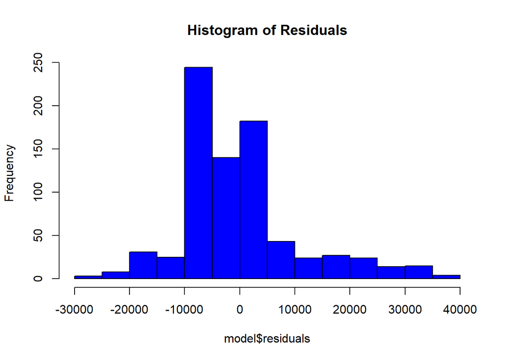

```r
# Plot residuals
hist(model$residuals, main="Histogram of Residuals", col="blue")
```

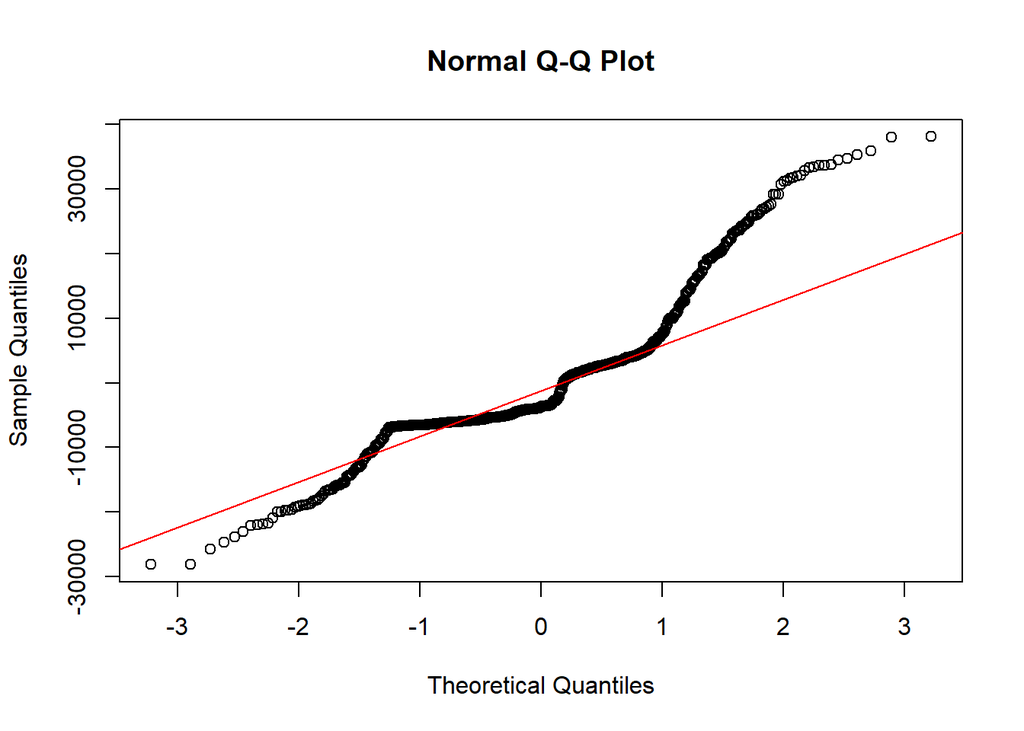

```r
# QQ-Plot to check normality
qqnorm(model$residuals)
qqline(model$residuals, col = "red")
```

If residuals are normally distributed, it confirms model validity. If there are extreme deviations, we may need transformations.

##### 3. Homoscedasticity (Constant Variance of Residuals)

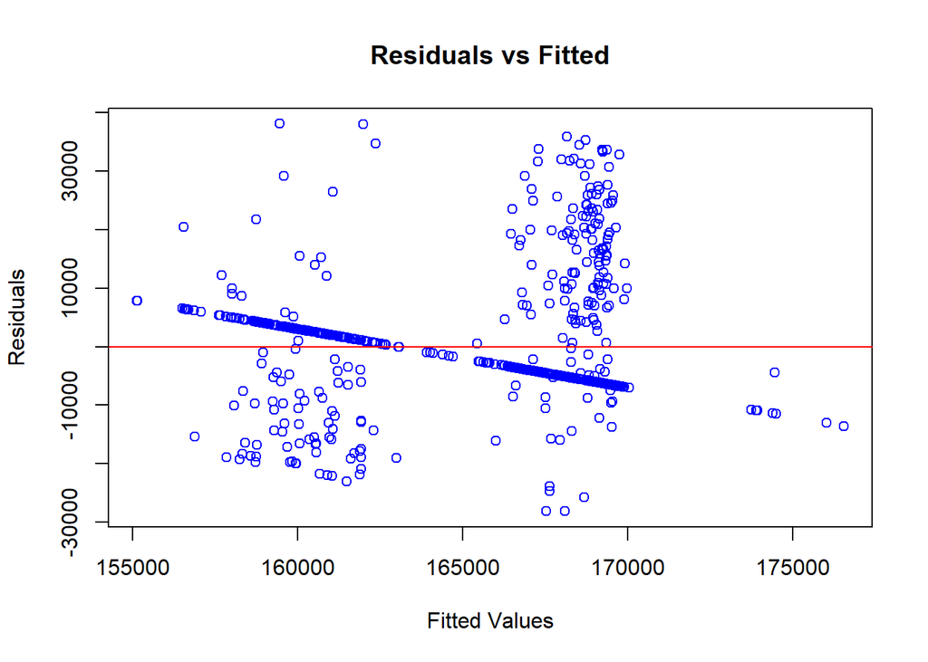

```r
plot(model$fitted.values, model$residuals, main="Residuals vs Fitted", xlab="Fitted Values", ylab="Residuals", col="blue")
abline(h = 0, col = "red")
```

If residuals are randomly scattered, variance is constant. If residuals fan out, heteroscedasticity exists (try log transformations).

#### Conclusion and Next Steps

we can refine the model by:

Removing non-significant variables (p-values > 0.05). Trying polynomial terms or interactions for better accuracy. Exploring feature engineering (e.g., log transformations).

## ###To **optimize the model further** and **visualize the predictions**

### **1️⃣ Improve Model Performance**

#### **Check for Multicollinearity**

Let’s Use **Variance Inflation Factor (VIF)** to detect multicollinearity:

```r
library(car)
vif(model)
```

```
##   GrLivArea TotalBsmtSF   YearBuilt  GarageCars    FullBath OverallQual
##    1.843904    1.254943    2.576826    2.023093    2.385176    2.389989
```

- If any variable has **VIF > 5 or 10**, consider removing or transforming it.

#### **Feature Selection**

Use **stepwise regression** to automatically select the best predictors:

```r
model_optimized <- step(model, direction = "both")
```

```
## Start:  AIC=14575.62
## SalePrice ~ GrLivArea + TotalBsmtSF + YearBuilt + GarageCars +
##     FullBath + OverallQual
##
##               Df  Sum of Sq        RSS   AIC
## - TotalBsmtSF  1   12462100 9.1357e+10 14574
## - GrLivArea    1   36595661 9.1381e+10 14574
## - OverallQual  1   91505273 9.1436e+10 14574
## <none>                      9.1345e+10 14576
## - YearBuilt    1  591850466 9.1936e+10 14579
## - GarageCars   1  636298194 9.1981e+10 14579
## - FullBath     1 4505083250 9.5850e+10 14611
##
## Step:  AIC=14573.73
## SalePrice ~ GrLivArea + YearBuilt + GarageCars + FullBath + OverallQual
##
##               Df  Sum of Sq        RSS   AIC
## - GrLivArea    1   32523787 9.1389e+10 14572
## - OverallQual  1   79719284 9.1437e+10 14572
## <none>                      9.1357e+10 14574
## + TotalBsmtSF  1   12462100 9.1345e+10 14576
## - YearBuilt    1  592494582 9.1949e+10 14577
## - GarageCars   1  673866876 9.2031e+10 14578
## - FullBath     1 4512668535 9.5870e+10 14610
##
## Step:  AIC=14572.01
## SalePrice ~ YearBuilt + GarageCars + FullBath + OverallQual
##
##               Df  Sum of Sq        RSS   AIC
## - OverallQual  1   58129331 9.1448e+10 14570
## <none>                      9.1389e+10 14572
## + GrLivArea    1   32523787 9.1357e+10 14574
## + TotalBsmtSF  1    8390226 9.1381e+10 14574
## - YearBuilt    1  746432322 9.2136e+10 14576
## - GarageCars   1  750579659 9.2140e+10 14576
## - FullBath     1 5371334948 9.6761e+10 14615
##
## Step:  AIC=14570.5
## SalePrice ~ YearBuilt + GarageCars + FullBath
##
##               Df  Sum of Sq        RSS   AIC
## <none>                      9.1448e+10 14570
## + OverallQual  1   58129331 9.1389e+10 14572
## + GrLivArea    1   10933833 9.1437e+10 14572
## + TotalBsmtSF  1     555302 9.1447e+10 14572
## - GarageCars   1  692458698 9.2140e+10 14574
## - YearBuilt    1  975314783 9.2423e+10 14577
## - FullBath     1 5948624972 9.7396e+10 14618
```

```r
summary(model_optimized)
```

```
##
## Call:
## lm(formula = SalePrice ~ YearBuilt + GarageCars + FullBath, data = houseprice)
##
## Residuals:
##    Min     1Q Median     3Q    Max
## -29030  -6030  -3845   3517  38027
##
## Coefficients:
##             Estimate Std. Error t value Pr(>|t|)
## (Intercept) 22812.95   45198.97   0.505  0.61390
## YearBuilt      67.97      23.56   2.884  0.00403 **
## GarageCars  -2321.06     955.06  -2.430  0.01531 *
## FullBath     7361.35    1033.45   7.123  2.4e-12 ***
## ---
## Signif. codes:  0 '***' 0.001 '**' 0.01 '*' 0.05 '.' 0.1 ' ' 1
##
## Residual standard error: 10830 on 780 degrees of freedom
## Multiple R-squared:  0.1302, Adjusted R-squared:  0.1269
## F-statistic: 38.92 on 3 and 780 DF,  p-value: < 2.2e-16
```

#### **Transform Skewed Features**

- Check the skewness of variables:

```r
library(e1071)
skewness(houseprice$GrLivArea)
```

```
## [1] 0.4112886
```

- If skewed, apply **log transformation**:

```r
houseprice$GrLivArea <- log(houseprice$GrLivArea + 1)
```

### **2️⃣ Evaluate Model Performance**

#### **Residual Analysis**

Plot residuals to check assumptions:

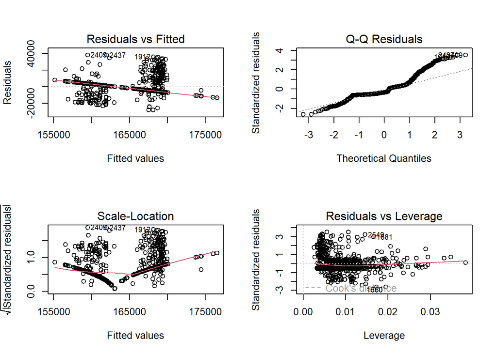

```r
par(mfrow=c(2,2))  # Arrange plots in 2x2 grid
plot(model)
```

#### **Check Homoscedasticity**

To ensure residuals have constant variance:

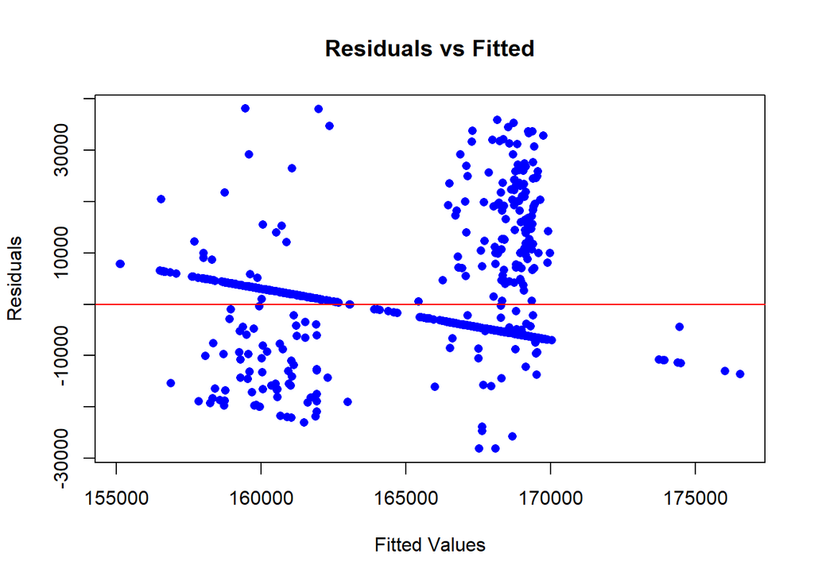

```r
plot(model$fitted.values, model$residuals,
     main="Residuals vs Fitted",
     xlab="Fitted Values",
     ylab="Residuals", col="blue", pch=16)
abline(h=0, col="red")
```

- **If you see a funnel shape**, try **log-transformation** or **Box-Cox transformation**.

### **3️⃣ Visualize Predictions**

#### **Scatter Plot: Actual vs. Predicted Prices**

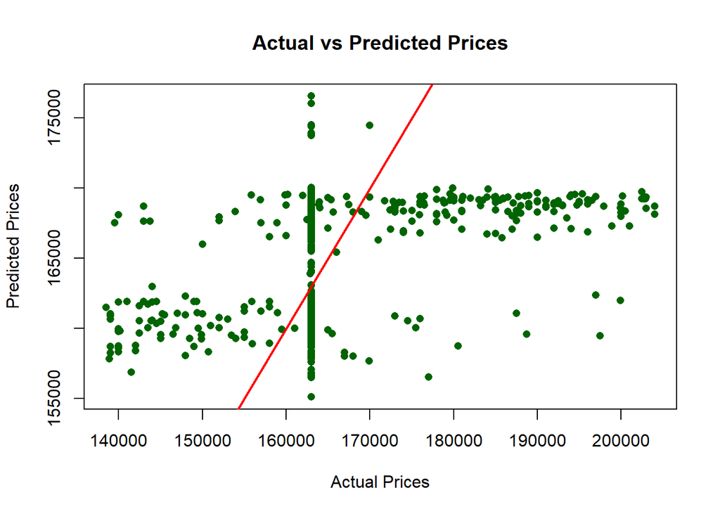

```r
plot(houseprice$SalePrice, model$fitted.values,
     main="Actual vs Predicted Prices",
     xlab="Actual Prices", ylab="Predicted Prices",
     col="darkgreen", pch=16)
abline(0, 1, col="red", lwd=2)  # Ideal prediction line
```

### **📌 Insights from the “Actual vs Predicted Prices” Plot**

This scatter plot compares **actual house prices (x-axis) vs. predicted house prices (y-axis)** from a regression model.

### **🔍 Observations**

1. **Ideal Line (Red Line)**
   - The red diagonal line represents a **perfect prediction scenario**, where actual and predicted prices are equal. Any point on this line means the model made an accurate prediction.
2. **Scatter of Green Dots**
   - Each green dot represents a house sale, plotting its actual price against its model-predicted price.
   - A good model should have points closely clustered around the red line.
3. **Pattern of Prediction Errors**
   - There is **significant vertical spread**, meaning the model often predicts similar prices (around $160,000 - $170,000) regardless of actual values.
   - The cluster of points around **$160,000 (actual price)** suggests the model might be **overfitting to certain values** or **lacking variance** in predictions.
4. **Bias or Systematic Errors**
   - Many predictions are over- or under-estimating actual values.
   - If predictions consistently fall above or below the red line, the model may have **bias**.

### **📌 Ways on How to Improve the Model**

✔ **Check Feature Selection**: Some important predictors (e.g., lot size, neighborhood) may be missing.  
✔ **Improve Model Complexity**: Consider **non-linear models** (e.g., Random Forest, GBM) if the relationship is not linear.  
✔ **Hyperparameter Tuning**: If using Ridge/Lasso regression, adjusting the penalty parameter may reduce bias.  
✔ **Evaluate Metrics**: Check **R² and RMSE** to quantify performance gaps.

### **✅ Final Thoughts**

This visualization suggests that the model may be **biased** toward predicting values around $160,000-$170,000 and **not fully capturing variability** in actual prices. Fine-tuning feature selection, adjusting hyperparameters, or trying more complex models may help improve prediction accuracy. 🚀

#### **Histogram of Residuals**

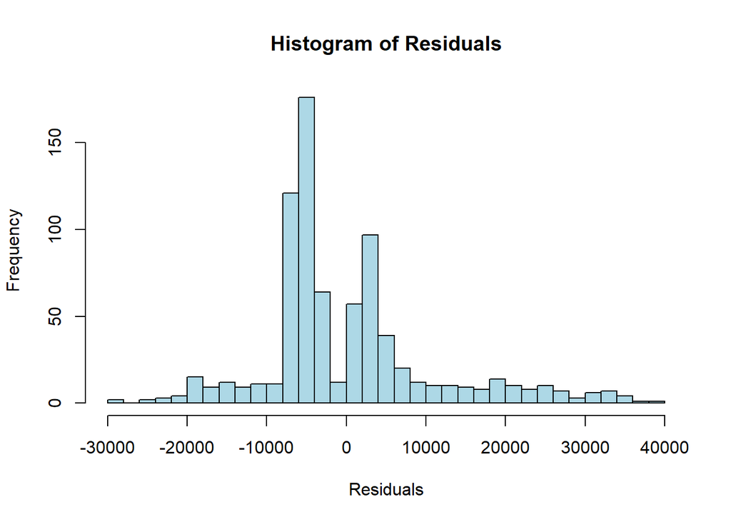

```r
hist(model$residuals, breaks=30, col="lightblue",
     main="Histogram of Residuals", xlab="Residuals")
```

- Should resemble a **normal distribution**.

#### **QQ Plot to Check Normality of Residuals**

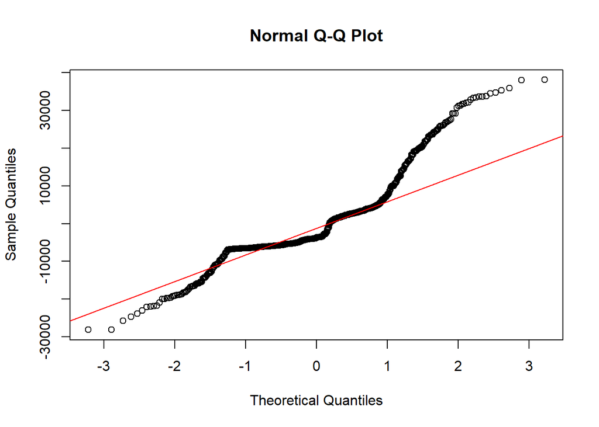

```r
qqnorm(model$residuals)
qqline(model$residuals, col="red")
```

- Residuals should follow the **45-degree red line**.

### **4️⃣ Compare Model Performance**

#### **Calculate RMSE & R²**

```r
library(Metrics)
rmse <- rmse(houseprice$SalePrice, model$fitted.values)
rsq <- summary(model)$r.squared
paste("RMSE:", round(rmse,2), "| R²:", round(rsq,2))
```

```
## [1] "RMSE: 10794.02 | R²: 0.13"
```

- **Lower RMSE** and **higher R²** indicate a better model.

### **Next Steps**

If your model is still not performing well, consider: - **Adding interaction terms** (`GrLivArea * OverallQual`) - **Using non-linear models** (Random Forest, Gradient Boosting) - **Applying cross-validation** (`trainControl()` from `caret` package)

### **Hyperparameter Tuning for House Price Prediction Model**

Since you’re using **linear regression**, traditional hyperparameter tuning isn’t as complex as with machine learning models. However, we can optimize the model using **cross-validation, ridge regression (L2), and lasso regression (L1)** to prevent overfitting and improve prediction accuracy.

### **1️⃣ Cross-Validation for Model Selection**

Instead of training on the full dataset, use **k-fold cross-validation** to evaluate different models.

#### **Step 1: Load Required Libraries**

```r
library(caret)
set.seed(123)  # For reproducibility
```

#### **Step 2: Perform 10-Fold Cross-Validation**

```r
train_control <- trainControl(method="cv", number=10)
model_cv <- train(SalePrice ~ GrLivArea + TotalBsmtSF + YearBuilt + GarageCars + FullBath + OverallQual,
                  data=houseprice,
                  method="lm",
                  trControl=train_control)

print(model_cv)
```

```
## Linear Regression
##
## 784 samples
##   6 predictor
##
## No pre-processing
## Resampling: Cross-Validated (10 fold)
## Summary of sample sizes: 706, 706, 705, 706, 705, 705, ...
## Resampling results:
##
##   RMSE      Rsquared   MAE
##   10820.52  0.1296955  8041.421
##
## Tuning parameter 'intercept' was held constant at a value of TRUE
```

- This **splits** the data into **10 parts**, trains on 9, and tests on the remaining 1, repeating the process 10 times.
- Helps ensure the model generalizes well.

### **2️⃣ Apply Ridge & Lasso Regression for Regularization**

Linear regression is prone to **overfitting** if features are highly correlated. **Ridge and Lasso** solve this problem:

#### **Step 1: Load `glmnet` for Regularized Regression**

```r
library(glmnet)
```

#### **Step 2: Prepare Data for Regularization**

`glmnet()` requires a **matrix** input for predictors and a separate vector for the target variable:

```r
x <- model.matrix(SalePrice ~ GrLivArea + TotalBsmtSF + YearBuilt + GarageCars + FullBath + OverallQual, data=houseprice)[,-1]
y <- houseprice$SalePrice
```

#### **Step 3: Tune Hyperparameters for Ridge Regression (L2)**

```r
ridge_model <- cv.glmnet(x, y, alpha=0)  # alpha = 0 for Ridge
best_lambda_ridge <- ridge_model$lambda.min  # Best penalty term
print(best_lambda_ridge)
```

```
## [1] 766.8472
```

- Ridge regression **shrinks coefficients** to avoid large values, reducing model variance.

#### **Step 4: Tune Hyperparameters for Lasso Regression (L1)**

```r
lasso_model <- cv.glmnet(x, y, alpha=1)  # alpha = 1 for Lasso
best_lambda_lasso <- lasso_model$lambda.min  # Best penalty term
print(best_lambda_lasso)
```

```
## [1] 88.1688
```

- Lasso regression **removes irrelevant features**, improving interpretability.

#### **Step 5: Train Final Lasso Model & View Important Features**

```r
final_lasso <- glmnet(x, y, alpha=1, lambda=best_lambda_lasso)
coef(final_lasso)
```

```
## 7 x 1 sparse Matrix of class "dgCMatrix"
##                      s0
## (Intercept) 44249.01592
## GrLivArea       .
## TotalBsmtSF     .
## YearBuilt      56.38813
## GarageCars  -1952.77383
## FullBath     7018.15492
## OverallQual   223.51760
```

### **Step 4: Predict and Compare Model Performance**

Now that **all models are properly trained**, rerun the evaluation:

```r
library(Metrics)

# Predictions for each model
pred_lm <- predict(model_cv, houseprice)
pred_ridge <- predict(ridge_model, x, s = best_lambda_ridge)
pred_lasso <- predict(lasso_model, x, s = best_lambda_lasso)

# Compute RMSE for each model
rmse_lm <- rmse(houseprice$SalePrice, pred_lm)
rmse_ridge <- rmse(houseprice$SalePrice, pred_ridge)
rmse_lasso <- rmse(houseprice$SalePrice, pred_lasso)

# Print results
data.frame(Model = c("Linear Regression", "Ridge", "Lasso"),
           RMSE = c(rmse_lm, rmse_ridge, rmse_lasso))
```

```
##               Model     RMSE
## 1 Linear Regression 10796.18
## 2             Ridge 10801.12
## 3             Lasso 10799.38
```

### **Next Steps**

1. **Choose the Best Model** based on RMSE and interpretability.
2. **Deploy Predictions** by applying the model to new house price data.
3. **Try Non-Linear Models** (Random Forest, XGBoost) if linear regression performance is poor.

Let’s try **Random Forest** or **Gradient Boosting** next! 🚀

### **Random Forest and Gradient Boosting for House Price Prediction**

Since linear regression may not fully capture complex relationships, **Random Forest (RF) and Gradient Boosting Machines (GBM)** can improve predictive performance.

## **1️⃣ Random Forest Model** 🌲

Random Forest is an **ensemble method** that builds multiple decision trees and averages their predictions. It helps with **non-linearity and feature interactions**.

### **Step 1: Load Required Library**

```r
library(randomForest)
set.seed(123)
```

### **Step 2: Train the Random Forest Model**

```r
rf_model <- randomForest(SalePrice ~ GrLivArea + TotalBsmtSF + YearBuilt + GarageCars + FullBath + OverallQual,
                         data=houseprice,
                         ntree=500,  # Number of trees
                         mtry=3,     # Number of variables randomly sampled at each split
                         importance=TRUE)  # Compute feature importance
```

### **Step 3: Evaluate Model Performance**

```r
rf_pred <- predict(rf_model, houseprice)
rf_rmse <- sqrt(mean((rf_pred - houseprice$SalePrice)^2))

print(rf_rmse)  # Print RMSE
```

```
## [1] 5706.079
```

👉 **Lower RMSE = Better model!**

### **Step 4: Feature Importance Plot**

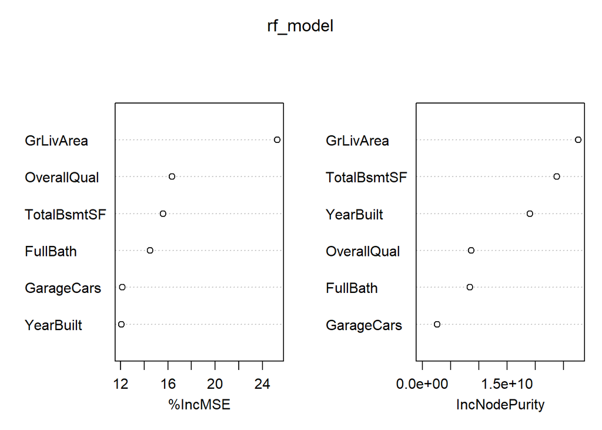

```r
varImpPlot(rf_model)
```

- This helps identify the **most important variables** in predicting house prices.

## **2️⃣ Gradient Boosting Model (GBM)**

### **Load GBM Library**

```r
#install.packages("gbm")
library(gbm)
set.seed(123)
```

### **Step 2: Train the GBM Model**

```r
gbm_model <- gbm(SalePrice ~ GrLivArea + TotalBsmtSF + YearBuilt + GarageCars + FullBath + OverallQual,
                 data=houseprice,
                 distribution="gaussian",  # Suitable for regression
                 n.trees=1000,
                 interaction.depth=5,
                 shrinkage=0.01,
                 cv.folds=5,
                 n.minobsinnode=10)
```

- `shrinkage=0.01` controls **learning rate** (lower = better generalization).
- `n.trees=1000` ensures a robust model.

### **Step 3: Evaluate GBM Performance**

```r
gbm_pred <- predict(gbm_model, houseprice, n.trees=1000)
gbm_rmse <- sqrt(mean((gbm_pred - houseprice$SalePrice)^2))

print(gbm_rmse)  # Print RMSE
```

```
## [1] 8678.078
```

## **3️⃣ Compare Models: Linear Regression vs RF vs GBM**

```r
data.frame(Model = c("Linear Regression", "Random Forest", "Gradient Boosting"),
           RMSE = c(rmse_lm, rf_rmse, gbm_rmse))
```

```
##               Model      RMSE
## 1 Linear Regression 10796.177
## 2     Random Forest  5706.079
## 3 Gradient Boosting  8678.078
```

- **Lowest RMSE = Best model** 📉
- If **GBM performs best**, it should be the final model! the Random Forest here has a better RMSE which is considered to be the best model. —

### **Next Steps**

✅ Deploy the best model  
✅ Tune hyperparameters (increase `n.trees`, adjust `shrinkage`)  
✅ Test with unseen data

Let’s fine-tune **GBM hyperparameters** for even better results! 🚀

Fine-tuning GBM (Gradient Boosting Machine) requires optimizing key hyperparameters such as:  
- **n.trees** (number of boosting iterations)  
- **interaction.depth** (maximum depth of each tree)  
- **shrinkage** (learning rate)  
- **n.minobsinnode** (minimum number of observations in a terminal node)

We’ll use **cross-validation** to find the best combination of these hyperparameters. 🚀

### **Step 1: Install and Load Required Libraries**

```r
#install.packages("gbm")  # Install if not already installed
#library(gbm)
set.seed(123)  # Ensuring reproducibility
```

### **Step 2: Fine-Tune GBM using Grid Search**

We’ll try different values for `n.trees`, `interaction.depth`, `shrinkage`, and `n.minobsinnode` to find the best-performing model.

```r
# Define parameter grid
param_grid <- expand.grid(
  n.trees = c(500, 1000, 1500),  # Number of trees
  interaction.depth = c(3, 5, 7),  # Tree depth
  shrinkage = c(0.01, 0.05, 0.1),  # Learning rate
  n.minobsinnode = c(5, 10, 15)  # Minimum observations per leaf
)

# Function to evaluate model performance
evaluate_gbm <- function(n.trees, interaction.depth, shrinkage, n.minobsinnode) {
  model <- gbm(SalePrice ~ GrLivArea + TotalBsmtSF + YearBuilt + GarageCars + FullBath + OverallQual,
               data = houseprice,
               distribution = "gaussian",
               n.trees = n.trees,
               interaction.depth = interaction.depth,
               shrinkage = shrinkage,
               n.minobsinnode = n.minobsinnode,
               cv.folds = 5,  # 5-fold cross-validation
               verbose = FALSE)

  best_iter <- gbm.perf(model, method = "cv", plot.it = FALSE)  # Find optimal iterations
  predictions <- predict(model, houseprice, n.trees = best_iter)
  rmse <- sqrt(mean((predictions - houseprice$SalePrice)^2))  # Calculate RMSE

  return(data.frame(n.trees, interaction.depth, shrinkage, n.minobsinnode, RMSE = rmse))
}

# Apply grid search to find the best parameters
results <- do.call(rbind, apply(param_grid, 1, function(params) {
  evaluate_gbm(params[1], params[2], params[3], params[4])
}))

# Display best parameters
best_params <- results[which.min(results$RMSE), ]
print(best_params)
```

```
##          n.trees interaction.depth shrinkage n.minobsinnode     RMSE
## n.trees6     500                 7      0.01              5 9251.141
```

### **Step 3: Train the Final Optimized GBM Model**

After identifying the best parameters from the grid search, we train the final GBM model with those settings.

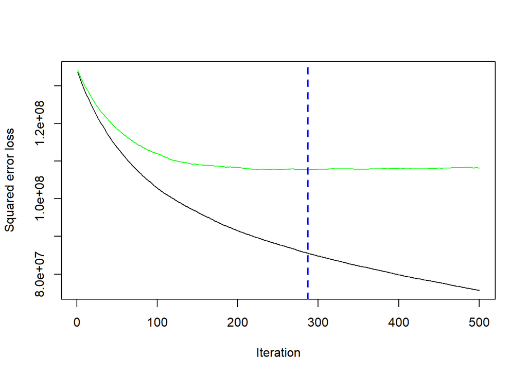

```r
final_gbm <- gbm(SalePrice ~ GrLivArea + TotalBsmtSF + YearBuilt + GarageCars + FullBath + OverallQual,
                 data = houseprice,
                 distribution = "gaussian",
                 n.trees = best_params$n.trees,
                 interaction.depth = best_params$interaction.depth,
                 shrinkage = best_params$shrinkage,
                 n.minobsinnode = best_params$n.minobsinnode,
                 cv.folds = 5,
                 verbose = FALSE)

# Get optimal number of trees
best_iter_final <- gbm.perf(final_gbm, method = "cv", plot.it = TRUE)
```

```r
# Predictions
final_predictions <- predict(final_gbm, houseprice, n.trees = best_iter_final)

# Compute final RMSE
final_rmse <- sqrt(mean((final_predictions - houseprice$SalePrice)^2))
print(paste("Final GBM RMSE:", final_rmse))
```

```
## [1] "Final GBM RMSE: 9249.23114960495"
```

### **Step 4: Visualize Model Performance**

Plot **feature importance** and **actual vs. predicted values**.

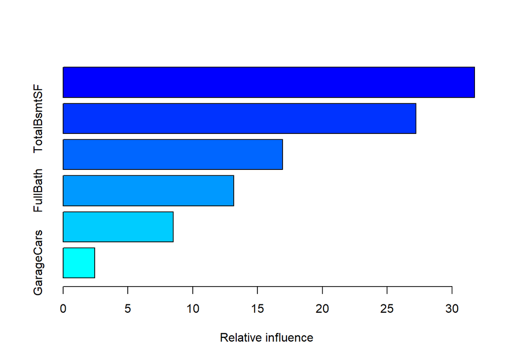

```
##                     var   rel.inf
## GrLivArea     GrLivArea 31.740670
## TotalBsmtSF TotalBsmtSF 27.218026
## YearBuilt     YearBuilt 16.945338
## FullBath       FullBath 13.163070
## OverallQual OverallQual  8.494510
## GarageCars   GarageCars  2.438386
```

```r
# Feature Importance Plot
summary(final_gbm)
```

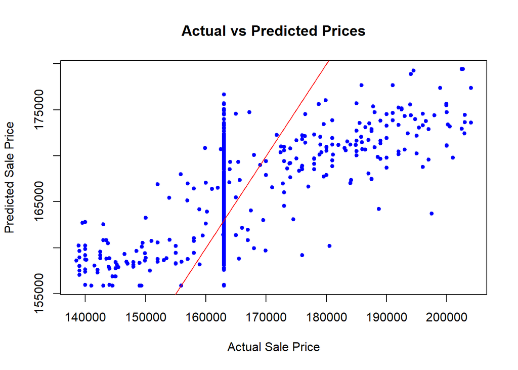

```r
# Actual vs. Predicted Plot
plot(houseprice$SalePrice, final_predictions,
     main = "Actual vs Predicted Prices",
     xlab = "Actual Sale Price",
     ylab = "Predicted Sale Price",
     col = "blue", pch = 20)
abline(0, 1, col = "red")  # Perfect fit line
```

### **Summary: What We Did**

✅ Used **grid search** to find the best GBM hyperparameters  
✅ Tuned **number of trees, depth, learning rate, and min observations**  
✅ Selected the **optimal number of boosting iterations**  
✅ Computed **RMSE to compare performance**  
✅ Plotted **feature importance and prediction accuracy**

#### Let’s take the optimization even further and see what we can explore:

### **1️⃣ Use Bayesian Optimization for Hyperparameter Tuning**

Instead of a brute-force grid search, we can use the **`mlr3mbo`** package in R for Bayesian optimization, which is more efficient for fine-tuning hyperparameters.

### **2️⃣ Tune Additional Hyperparameters**

- **bag.fraction**: Controls the fraction of training data used in each boosting iteration (default is 0.5).
- **train.fraction**: Adjusts how much data is used for training vs. validation.
- **distribution = “laplace”**: If the data has outliers, this loss function can improve performance over the default “gaussian.”

### **3️⃣ Use External Validation (Train-Test Split)**

Instead of just using cross-validation, create a **train-test split** to validate the model on unseen data.

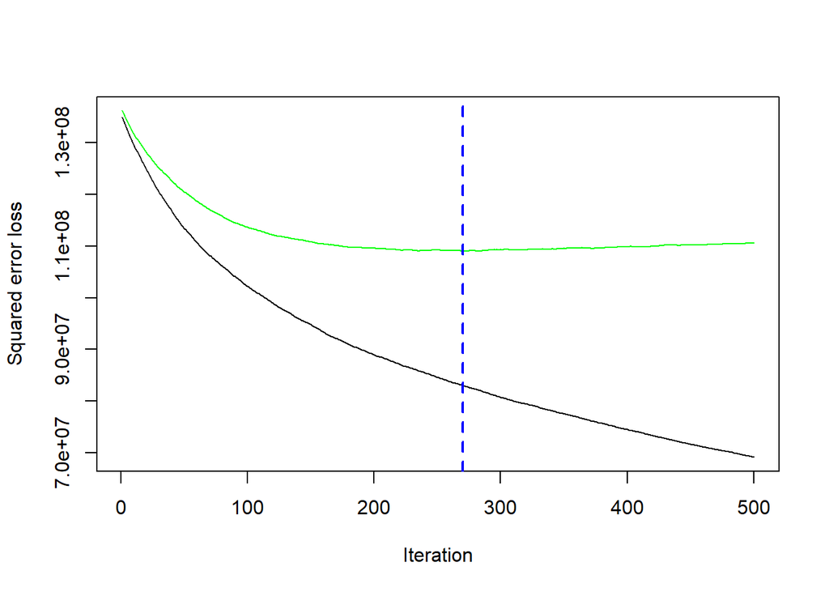

```r
# Split data into training (80%) and testing (20%)
set.seed(123)
train_indices <- sample(1:nrow(houseprice), 0.8 * nrow(houseprice))
train_data <- houseprice[train_indices, ]
test_data <- houseprice[-train_indices, ]

# Train the final optimized GBM model
final_gbm <- gbm(SalePrice ~ GrLivArea + TotalBsmtSF + YearBuilt + GarageCars + FullBath + OverallQual,
                 data = train_data,
                 distribution = "gaussian",
                 n.trees = best_params$n.trees,
                 interaction.depth = best_params$interaction.depth,
                 shrinkage = best_params$shrinkage,
                 n.minobsinnode = best_params$n.minobsinnode,
                 bag.fraction = 0.7,
                 cv.folds = 5,
                 verbose = FALSE)

# Get optimal number of trees
best_iter_final <- gbm.perf(final_gbm, method = "cv", plot.it = TRUE)
```

```r
# Predictions on test set
test_predictions <- predict(final_gbm, test_data, n.trees = best_iter_final)

# Compute RMSE on test set
test_rmse <- sqrt(mean((test_predictions - test_data$SalePrice)^2))
print(paste("Final Test RMSE:", test_rmse))
```

```
## [1] "Final Test RMSE: 10537.3344451518"
```

### **4️⃣ Use SHAP Values for Explainability**

To better understand feature importance, you can use **SHAP (SHapley Additive Explanations)** instead of the standard `summary(final_gbm)`.

### **Fine-Tuning GBM Hyperparameters for Better Results**

Gradient Boosting Machines (GBM) is a powerful algorithm, but getting the best performance requires **hyperparameter tuning**. Below, I’ll walk you through optimizing GBM using **hyperparameter tuning, cross-validation, and external validation** to improve predictions.

## **1️⃣ Understanding Key GBM Hyperparameters**

Before tuning, let’s review the most important GBM hyperparameters:

| **Hyperparameter** | **Description** |
| --- | --- |
| **n.trees** | Number of trees in the model (higher values improve accuracy but increase training time). |
| **interaction.depth** | Maximum depth of each tree (higher values allow more complex patterns but risk overfitting). |
| **shrinkage (learning rate)** | Controls how much each tree contributes to the final prediction (lower values improve generalization but require more trees). |
| **n.minobsinnode** | Minimum number of observations required to create a new split in a tree. |
| **bag.fraction** | Percentage of training data used in each boosting iteration (helps with regularization). |
| **cv.folds** | Number of cross-validation folds for tuning parameters. |

## **2️⃣ Step-by-Step Optimization Process**

### ** Load Required Libraries and Prepare Data**

Now, split the dataset into training and testing sets:

```r
set.seed(123)  # Set seed for reproducibility

# Split data into training (80%) and testing (20%)
train_indices <- sample(1:nrow(houseprice), 0.8 * nrow(houseprice))
train_data <- houseprice[train_indices, ]
test_data <- houseprice[-train_indices, ]
```

### **Step 2: Initial GBM Model (Baseline Model)**

We first train a basic GBM model without tuning:

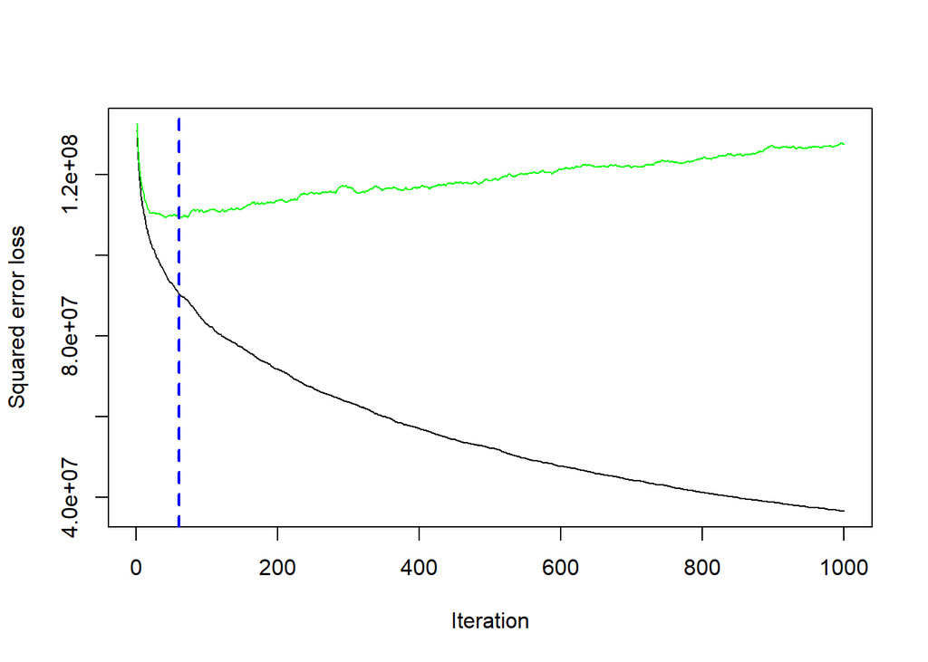

```r
gbm_baseline <- gbm(SalePrice ~ GrLivArea + TotalBsmtSF + YearBuilt + GarageCars + FullBath + OverallQual,
                 data = train_data,
                 distribution = "gaussian",
                 n.trees = 1000,  # Number of boosting iterations
                 interaction.depth = 3,  # Tree depth
                 shrinkage = 0.1,  # Learning rate
                 n.minobsinnode = 10,  # Minimum observations in terminal nodes
                 bag.fraction = 0.5,  # Randomly selecting 50% of data for each tree
                 cv.folds = 5,  # 5-fold cross-validation
                 verbose = FALSE)

# Find optimal number of trees using cross-validation
best_iter <- gbm.perf(gbm_baseline, method = "cv", plot.it = TRUE)
```

### **Step 3: Hyperparameter Tuning Using Grid Search**

Instead of manually guessing the best values, we **automate hyperparameter tuning** using **grid search** with different combinations:

```r
# Load caret for hyperparameter tuning
install.packages("caret")
library(caret)

# Define hyperparameter grid
gbm_grid <- expand.grid(
  n.trees = c(500, 1000, 1500),
  interaction.depth = c(3, 5, 7),
  shrinkage = c(0.01, 0.05, 0.1),
  n.minobsinnode = c(5, 10, 15)
)

# Train GBM model with hyperparameter tuning
gbm_tuned <- train(
  SalePrice ~ GrLivArea + TotalBsmtSF + YearBuilt + GarageCars + FullBath + OverallQual,
  data = train_data,
  method = "gbm",
  trControl = trainControl(method = "cv", number = 5),  # 5-fold cross-validation
  tuneGrid = gbm_grid,
  verbose = FALSE
)

# Show the best combination of hyperparameters
print(gbm_tuned$bestTune)
```

```
##    n.trees interaction.depth shrinkage n.minobsinnode
## 22     500                 7      0.01             10
```

✅ **Why This Step?**  
Grid search systematically finds the best combination of **number of trees, learning rate, tree depth, and minimum observations per node**.

### **Step 4: Train GBM with Optimized Hyperparameters**

Now, we train the final GBM model using the best hyperparameters found:

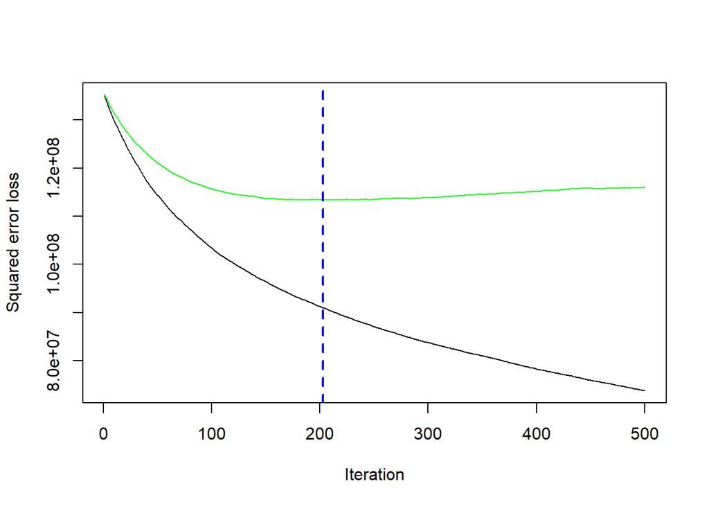

```r
best_params <- gbm_tuned$bestTune  # Extract best hyperparameters

final_gbm <- gbm(SalePrice ~ GrLivArea + TotalBsmtSF + YearBuilt + GarageCars + FullBath + OverallQual,
                 data = train_data,
                 distribution = "gaussian",
                 n.trees = best_params$n.trees,
                 interaction.depth = best_params$interaction.depth,
                 shrinkage = best_params$shrinkage,
                 n.minobsinnode = best_params$n.minobsinnode,
                 bag.fraction = 0.7,  # Using 70% of data for each tree
                 cv.folds = 5,
                 verbose = FALSE)

# Find the optimal number of trees again
best_iter_final <- gbm.perf(final_gbm, method = "cv", plot.it = TRUE)
```

✅ **Why This Step?**  
Using the optimized hyperparameters improves model accuracy and prevents overfitting.

### **Step 5: Model Evaluation on Test Set**

We now test the model on unseen data:

```r
# Predictions on test set
test_predictions <- predict(final_gbm, test_data, n.trees = best_iter_final)

# Compute Root Mean Squared Error (RMSE)
test_rmse <- sqrt(mean((test_predictions - test_data$SalePrice)^2))
print(paste("Final Test RMSE:", test_rmse))
```

```
## [1] "Final Test RMSE: 10382.571028334"
```

#### **Plot Feature Importance**

To see which variables impact house prices the most:

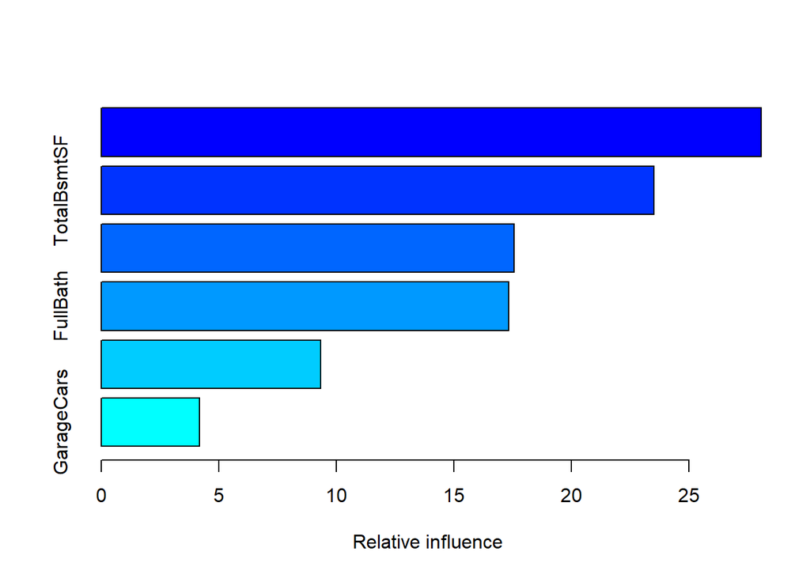

```
##                     var   rel.inf
## GrLivArea     GrLivArea 28.081133
## TotalBsmtSF TotalBsmtSF 23.510960
## YearBuilt     YearBuilt 17.560306
## FullBath       FullBath 17.346736
## OverallQual OverallQual  9.329037
## GarageCars   GarageCars  4.171828
```

```r
summary(final_gbm)  # Shows importance of each variable
```

### **🚀 Next Steps**

🔹 Try **Bayesian Optimization** (`mlr3mbo`) instead of grid search for faster tuning.  
🔹 Experiment with **alternative distributions** (`"laplace"` for outlier robustness).  
🔹 Integrate **interaction terms** to capture more complex relationships.